# UK Baker Folder Structure

Rodrigo Canovas

[Baker Bioinformatics](https://intranet.baker.edu.au/research-resources/platform-technologies/bioinformatics-program/) - 14 September 2021

This document present the folder structure used to store the UK Biobank version 3 on the Baker Institute cluster. On the following sections we described the data stored within each folder and provide links to get more detailed information. The current folder structure is as follow:

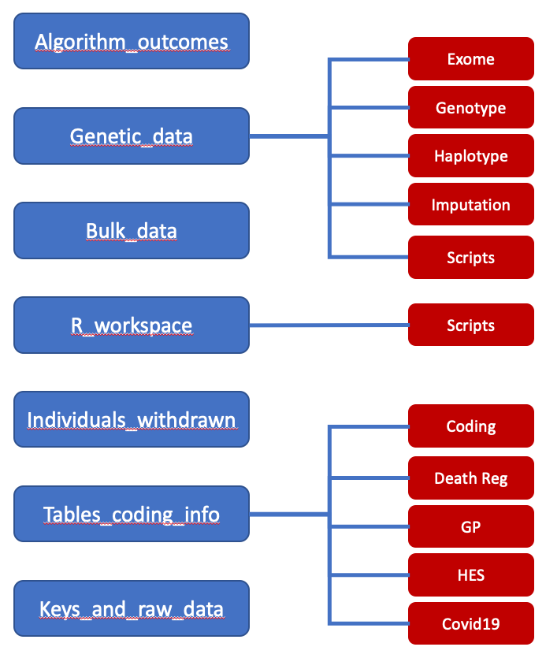

General folder structure

# Algorithm outcomes

This folder contains the documents presented on the [Algorithmically-defined outcomes](https://biobank.ctsu.ox.ac.uk/crystal/label.cgi?id=42) field on the UK Biobank, which describe how to compute each outcome and the fields on UKB which have the pre-computed values for the following conditions:

- Asthma
- COPD
- Dementia outcomes
- End stage renal disease
- Motor neurone disease
- Myocardial infarction
- Parkinson’s disease
- Stroke

Please note that these fields have not been updated since the March 2019 Showcase update. You might, therefore, find discrepancies between these algorithms and other health outcome fields

# Bulk data

This folder contains any bulk data (ex. imaging, accelerometer or ECG data) that have been downloaded. Given the size of this kind of data, most of the files downloaded here are only kept while someone is using them.

In order to get access/download bulk data, please contact the bioinformatic team.

# Genetic data

This folder contains the genetics data of the UKB individuals. There are a variety of different types of genetics data available through UK Biobank and each of them was stored on its own folder. Within each folder we have included READMEs files describing in more details the information stored.

Additionally, in the Script folder, you can find instructions and scripts to work and analyse the genetic data (ex. how to perform a GWAS analysis).

## Exome

Currently, the UKB provide Exome sequences for 200,000 participants, which was downloaded as [Population level exome OQFE variants, PLINK format](https://biobank.ctsu.ox.ac.uk/showcase/field.cgi?id=23155).

The first tranche of UK Biobank whole exome sequencing (WES) was made available for 50,000 UK Biobank participants in March 2019, and the data for an additional 150,000 participants was made available in October 2020. Initially data was computed using two protocols, FE and SPB, however these were replaced by a new improved unified OQFE pipeline when the additional 150,000 sequences were released (with the earlier values being reprocessed to match this).

For more information click [here](https://biobank.ctsu.ox.ac.uk/crystal/label.cgi?id=170)

## Genotype

The UKB provide Genome-wide genetic data for 488,000 participants. Several genotype information is available in the UKB and we divided it in different folders. For more information click [here](https://biobank.ctsu.ox.ac.uk/crystal/label.cgi?id=263)

### Plink

The genotype calls are in binary PLINK format (.bed, .bim, .fam) and the positions are in GRCh37 coordinates. Note that each of the part of the plink format (.bed, .bim, .fam) where downloaded separatly and prefix names are not the same.

### QC

In this folder we stored the file containing the quality control information of the SNPs and Indels in the data set. It is a plaintext file with space separated columns (for more information click [here](https://biobank.ctsu.ox.ac.uk/crystal/refer.cgi?id=1955)).

Additionaly most of the samples QC has been included into the main data now. For more information click [here](https://biobank.ctsu.ox.ac.uk/crystal/label.cgi?id=100313)

### CNV

These files contain the B-Allele-Frequency (baf) and Log2Ratio (log2r) transformed intensitiy values for performing Copy Number Variation (CNV) calling. There is a separate file for baf and log2r per chromosome. These are plaintext files with space separated columns. The rows corresond to markers (ordered as the calls BIM file) and the columns correspond to samples (ordered as the calls FAM file). Missing values are represented by -1.

### Confidence

These files contain the Affymetrix ‘confidence’ that a genotype belongs to the call cluster. This is a plaintext file with space spearated columns. Values are in the range 0-1 with 0 being most confident. Missing values are represented by -1. The order of markers and Samples are given by the BIM and FAM files.

### Intensity

These files contains the A,B intensity data measured by Affymetrix. The files are in a simple custom binary format. There are two intensity values A,B for each genotype, each represented as a 4-byte float. The set of A,B values for each marker are ordered consecutively by sample (analagous to a matrix with rows=SNPs and columns=Samples) e.g.

SNP_1_SAMPLE_1_A SNP_1_SAMPLE_1_B SNP_1_SAMPLE_2_A SNP_1_SAMPLE_2_B … SNP_1_SAMPLE_N_A SNP_1_SAMPLE_N_B SNP_2_SAMPLE_1_A SNP_2_SAMPLE_1_B …

Missing pairs of intensities are represented by -1 -1. The order of the markers and Samples are given by the BIM and FAM files with the calls.

Affymetrix transform the A,B values into ‘contrast’ and ‘strength’ for their calling algorithm. If the intensity data is to be used for making cluster plots it is strongly suggested that the transformed values are plotted. The ellipses described by the snp-posterior data are only compatible with the transformed intensity values.

- contrast (X) = log2(A/B)
- strength (Y) = log2(AB)/2

Affymetrix called the genotypes in (106) batches of ~4,700 samples. To accurately examine the cluster plots, each batch should be plotted separately for a given marker. For chrX, males and females were called separately, so males and females should be plotted separately for chrX markers.

### Relatedness

This file lists the pairs of individuals related up to the third degree in the data set. It is a plaintext file with space separated columns.

[output not shown]

### SNP-posterior

These files contain parameters used in Affymetrix’s genotype calling algorithm, such as the posterior probability distributions (2-dimensional multivariate Normal) for intensities (in ‘contrast’ and ‘strength’ coordinates) of each genotype at each marker. See the Applied Biosystems Axiom Genotyping Solution Data Analysis Guide for more details [here](http://tools.thermofisher.com/content/sfs/manuals/axiom_genotyping_solution_analysis_guide.pdf).

Affymetrix provide 33 parameters per marker per batch (3,498 per marker). Each parameter is represented by a 4-byte float. The set of values for each marker are ordered consecutively by batch. This is analagous to a matrix with rows=markers and columns=batch_parameters. The order of the markers and batches are given by the BIM and Batch files.

Diploid and haploid SNPs are called differently in Affymetrix’ calling pipeline. On chrX females are diploid and males are haploid so we get two sets of parameters per SNP per batch. In the .bin snp-posterior chrX file, for each SNP the diploid and then the haploid snp-posteriors are given consecutively. The order of the SNPs is given in the BIM files, the haploid SNPs on chrX are appended with ‘:1’ following Affymetrix’ notation. The BIM files for chr1-22,Y,XY,MT are the same as for the calls files (plink), but the chrX SNP-posterior BIM file has twice as many lines.

The 33 parameters are arranged in four groups. There are 7 parameters for each genotype cluster BB, AB, AA and a fourth set of 12 parameters (CV) from Affymetrix’ pipeline which can be ignored for most analyses. The 7 parameters per genotype cluster are five parameters which define a 2-dimensional multivariate Normal distribution, and two counts of observations (NObsMean,NObsVar) in the order:

- mu_X
- sigma_X
- NObsMean
- NObsVar
- mu_Y
- sigma_Y
- cov

Missing values are represented using the IEEE 754 NaN.

## Haplotype

The phased haplotypes are in BGEN v1.2 format (.bgen, .sample, .bgi). The sample file lists the order of the samples in the .bgen files.

Note that the .sample files are located in the Imputation folder

## Imputation

We stored the original imputation data on the bgen folder and precomputed versions on the pgen folder.

### Bgen

The imputed genotype calls are in BGEN v1.2 format (.bgen, .sample, .bgi). The sample file lists the order of the samples in the .bgen files. The sample file includes the ‘Sex’ field for every sample (corresponding to ‘Inferred.Gender’ in the Sample-QC file). The list of variants in the files can be found with bgenix [here](https://bitbucket.org/gavinband/bgen/wiki/bgenix). The 1st column of the marker list file is ‘alternate_ids’ which is a unique identifier for each marker. For markers in the genotype data set ‘alternate_ids’ is the genotype marker id (rs_id in SNP-QC file). The second column is rsid or the reference panel marker_id, it is not guaranteed to be unique. The alleles in the imputation are aligned with REF/ALT, first_allele is the ref allele on the fwd strand.

Also, in this folder we stored the Imputation MAF+info which lists the minor allele frequency and info score for each of the markers in the imputed data, calculated using QCTOOL. The order of markers in these files is not guaranteed to be the same as the BGEN files. The information have been stored on the following order:

- Alternate_id
- RS_id
- Position
- Allele1
- Allele2
- MAF
- Minor Allele
- Info score

In the last UKB realese the HLA imputation information was included as part of the main data instead of independ file (more information [here](https://biobank.ndph.ox.ac.uk/showcase/field.cgi?id=22182)

### Pgen

We generated the following pgen format version of the original downloaded bgen imputed data:

- all: Literaly, a complete version of the bgen data without doing any filtering
- basic_filter: A minimal quality controlled and filtered dataset where
  - Individuals that are not presented in the phenotpe/trait data downloaded, were excluded. Note that not all individuals have information for all the phenotypes and traits.
  - SNPs with INFO <= 0.01 where excluded
  - Multiallelic SNPs were excluded
  - Snps with Maf <= 0.001 where excluded
- stringent_filter: A stringent quality controlled and filtered dataset where
  - Individuals that are not presented in the phenotpe/trait data downloaded, were excluded. Note that not all individuals have information for all the phenotypes and traits.
  - SNPs with INFO <= 0.4 where excluded
  - Multiallelic SNPs were excluded
  - Snps with Maf <= 0.01 where excluded

Notice that some INDELs may still be present and that there still may be some multiallelic cases, because we only check for SNPs with same rsid (instead of also checking pos:chr information). To do extra QC or filter these SNPs please refer to the scripts folder.

# Keys and raw data

This folder contains the information related to all the phenotypes and traits available fields on the UK Biobank data. This includes all the keys and encoded information downloaded from the UKB. For each version of the main data downloaded, we generated the following files:

- CSV: Comma-separated file output with all fields double-quoted (to account for possible text fields containing commas).
- TXT: A basic tab-separated text file output. As for csv above, the Data-Codings will be retained rather than replaced by their meanings.
- R (tab/r): The .tab file containing the data, in a tab-separated format and could potentially be imported directly into R, but none of the values will be coded. Meanwhile, the .r file should be opened and executed in R (or any other R environment, such as RStudio). It contains a list of commands that will import the dataset (as a data.frame named bd) and recode all categorical variables.
- HTML: Document that lists information about the structure of the dataset.

Stata and sas format of the data can be generated on request

# R workspace

In order to facilate the use of the UK Biobank trait and phenotype data, we generated precomputed R datasets containing all the information. The following R data sets were generated:

- date_ukb_data.rda : (ukb_data and ukb_data_key) All individuals (~500K) phenotypes and traits. The date is the formar YYMMDD.
- date_ukb_data_clean.rda : Individuals with no genotype and individual who have withdrawn UKB were excluded from this set (after filtering ~487K individuals).
- date_ukb_exome.rda : Individuals from cleaned data such that they have exome information (~200K individuals)

## Scripts

This folder contains scripts and source that could help to navigate and extract data from the R workspace and analysing/filtering data

- R-env data scripts:
  - ukb_create_main_data.R
  - ukb_clean_main_data.R
  - ukb_functions.R

# Individuals withdrawn

This folder contains the list of individuals that have withdraw from UK Biobank.

- w55469_20200820.csv: individuals that have withdraw from UK Biobank (until 20/08/20)
- w55469_20210201.csv: individuals that have withdraw from UK Biobank (until 01/02/21)
- w55469_20210809.csv: individuals that have withdraw from UK Biobank (until 09/08/21)

# Tables coding info

The UK Biobank has been making more frequent updates of death and hospital inpatient data (including critical care admissions) on the Data Portal as well as specific Covid19 data. We have been keeping archives of all available updated version until the 14/09/2021 and we will keep updating the data once a month. The current available tables are:

| Dataset | Table name | Row Counts | Last Updated |
| --- | --- | --- | --- |
| COVID19 miscellaneous | covid19_misc | 487373 | 14/08/2020 |
| COVID19 test results | covid19_result | 157883 | 19/05/2021 |
| COVID19 test results (England) | covid19_result_england | 237809 | 09/09/2021 |
| COVID19 test results (Scotland) | covid19_result_scotland | 37210 | 25/08/2021 |
| COVID19 test results (Wales) | covid19_result_wales | 18473 | 12/08/2021 |
| Death causes | death_cause | 86604 | 08/04/2021 |
| Death records | death | 35093 | 08/04/2021 |
| GP clinical events | gp_clinical | 123669371 | 07/09/2019 |
| GP clinical events (EMIS, COVID19) | covid19_emis_gp_clinical | 296587375 | 10/08/2021 |
| GP clinical events (TPP, COVID19) | covid19_tpp_gp_clinical | 150169049 | 20/05/2021 |
| GP prescriptions | gp_scripts | 57709810 | 07/09/2019 |
| GP prescriptions (EMIS, COVID19) | covid19_emis_gp_scripts | 88780145 | 10/08/2021 |
| GP prescriptions (TPP, COVID19) | covid19_tpp_gp_scripts | 72126758 | 20/05/2021 |
| GP registrations | gp_registrations | 361841 | 07/09/2019 |
| HES inpatient core dataset | hesin | 3799429 | 08/06/2021 |
| HES inpatient critical care | hesin_critical | 32360 | 08/06/2021 |
| HES inpatient delivery | hesin_delivery | 33249 | 08/06/2021 |
| HES inpatient diagnoses | hesin_diag | 14416549 | 08/06/2021 |
| HES inpatient maternity | hesin_maternity | 30974 | 08/06/2021 |
| HES inpatient operations | hesin_oper | 7744357 | 08/06/2021 |
| HES inpatient psychiatric | hesin_psych | 3341134 | 08/06/2021 |
| HES inpatient birth (don't have access approval) | hesin_birth | 33184 | 07/09/2019 |

For more information, please refer to the README within each subfolder. For more information about last updates check the following links:

- [Covid19 updates](http://biobank.ndph.ox.ac.uk/showcase/exinfo.cgi?src=COVID19)
- [Time Lines All](http://biobank.ndph.ox.ac.uk/showcase/exinfo.cgi?src=timelines_all)

## Death Register

For more informatin please refer to the documents located in the UK Biobank [here](https://biobank.ndph.ox.ac.uk/showcase/refer.cgi?id=115559)

## GP

Primary care data. Note that this table have not been updated since September 2019.

For more information check [here](https://biobank.ndph.ox.ac.uk/showcase/refer.cgi?id=591)

## HES

Hospital inpatient data. For more information:

- [Description](http://biobank.ndph.ox.ac.uk/showcase/refer.cgi?id=138483)
- [Table items](http://biobank.ndph.ox.ac.uk/showcase/refer.cgi?id=141140)

## Covid19

UK Biobank are now receiving COVID-19 test data for UK Biobank participants, as well as primary care (GP) data specifically for use in COVID-19 research. Any COVID-19 related research can be done under an existing MTA for an approved project, with no changes or additional fees.

For more information, please refer to the README within each subfolder and the following links:

- [Covid19 Data](https://biobank.ndph.ox.ac.uk/showcase/exinfo.cgi?src=COVID19)
- [Testing](https://biobank.ndph.ox.ac.uk/showcase/exinfo.cgi?src=COVID19_tests)
- [Covid19 GP](https://biobank.ndph.ox.ac.uk/showcase/refer.cgi?id=3151)

## Codings

Also, we have including the Coding folder that contains files with ICD10 mappings to other types of codes

- coding1834.tsv: TRUD mapping of Read2 into 3-character ICD10
- coding1835.tsv: TRUD mapping of Read3 (CTV3) into 3-character ICD10
- coding609.tsv: Self-reported mapping into 3-character ICD10
- coding1836.tsv: ICD-9 codes into 3-character ICD10

A work by [Baker Bioinformatics](https://intranet.baker.edu.au/research-resources/platform-technologies/bioinformatics-program/)

*bioinformatics@baker.edu.au*